# 13 In-Class Assignment: Projections

[figure not shown]

Image from: https://en.wikipedia.org/wiki/Vector_projection

### Agenda for today's class (80 minutes)

1. (20 minutes) Pre-Class Review
2. (30 minutes) Understanding Projections with Code
3. (30 minutes) Gram-Schmidt Orthoganalization Process

## 1. Pre-class Review

- 13--Projections_pre-class-assignment

## 2. Understanding Projections With Code

In this in-class assignment, we are going to avoid some of the more advanced libraries ((i.e. no `numpy` or `scipy` or `sympy`) to try to get a better understanding about what is going on in the math. The following code implements some common linear algebra functions:

```python
#Standard Python Libraries only
import math
import copy
```

```python
def dot(u,v):
    '''Calculate the dot product between vectors u and v'''
    if len(u) != len(v):
        print("ERROR -  dimensions not equal")
    else:
        temp = 0;
        for i in range(len(u)):
            temp += u[i]*v[i]
        return temp
```

```python
def multiply(m1,m2):
    '''Calculate the matrix multiplication between m1 and m2 represented as list-of-list.'''
    n = len(m1)
    d = len(m2)
    m = len(m2[0])

    if len(m1[0]) != d:
        print("ERROR - inner dimentions not equal")
    else:
        result = [[0 for i in range(n)] for j in range(m)]
        for i in range(0,n):
            for j in range(0,m):
                for k in range(0,d):
                    result[i][j] = result[i][j] + m1[i][k] * m2[k][j]
        return result
```

```python
def add_vectors(v1,v2):
    v3 = []
    for i in range(len(v1)):
        v3.append(v1[i]+v2[i])
    return v3
```

```python
def sub_vectors(v1,v2):
    v3 = []
    for i in range(len(v1)):
        v3.append(v1[i]-v2[i])
    return v3
```

```python
def norm(u):
    '''Calculate the norm of vector u'''
    nm = 0
    for i in range(len(u)):
        nm += u[i]*u[i]
    return math.sqrt(nm)
```

```python
def transpose(A):
    '''Calculate the transpose of matrix A represented as list of lists'''
    n = len(A)
    m = len(A[0])
    AT = list()
    for j in range(0,m):
        temp = list()
        for i in range(0,n):
            temp.append(A[i][j])
        AT.append(temp)
    return AT
```

### Projection function

✅ **DO THIS:** Write a function that projects vector $v$ onto vector $u$. Do not use the numpy library. Instead use the functions provided above:

$$\mbox{proj}_u v = \frac{v \cdot u}{u \cdot u} u$$

Make sure this function will work for any size of $v$ and $u$.

```python
def proj(v,u):
    ## Put your code here
    n = dot(u,v)
    d = norm(u)**2
    pv = []
    for i in u:
        pv.append(n/d *i)
    return pv
```

Let's test your function. Below are two example vectors. Find the projection of v onto u. Note that the order of variables in your function `proj(.,.)` matters! Make sure you get the correct answers. You may want to test this code with more than one set of vectors.

```python
u = [1,2,0,3]
v = [4,0,5,8]
print(proj(v,u))
```

```
[2.0, 4.0, 0.0, 6.0]
```

```python
from answercheck import checkanswer

checkanswer.vector(proj(v,u),'b400dee73da5b8fa07602efd89f20ac1');
```

````
CheckWarning: passed variable is <class 'list'> and not a numpy.matrix.
    Trying to convert to a array matrix using ```A = np.matrix(A)```.


CheckWarning: Vector contains negative values for zero...
    Converting to positive values of zero using  ```A[A==-0] = 0```.

Testing [[2. 4. 0. 6.]]
Answer seems to be correct
````

### Visualizing projections

✅ **DO THIS:** See if you can design and implement a small function that takes two vectors ($a$ and $b$) as inputs and generates a figure similar to the one above.

I.e. a black line from the origin to "$b$", a black line from origin to "$a$"; a green line showing the "$a$" component in the "$b$" direction and a red line showing the "$a$" component orthogonal to the green line. Also see section titled "Projection of One Vector onto Another Vector" in Section 4.6 on page 258 of the book.

When complete, show your solution to the instructor.

```
[[1.8461538461538465, 2.7692307692307696]]
```

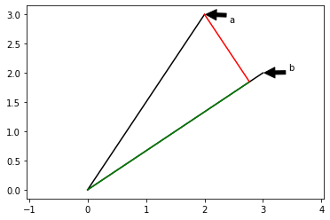

```python
%matplotlib inline
import matplotlib.pylab as plt

b = [3,2]
a = [2,3]
c = [proj(b,a)]
print(c)

def show_projection(a,b):
    plt.plot([0,a[0]], [0,a[1]], color='black')
    plt.annotate('b', b,
            xytext=(0.9, 0.7), textcoords='axes fraction',
            arrowprops=dict(facecolor='black', shrink=0.05),
            horizontalalignment='right', verticalalignment='top')
    plt.annotate('a', a,
            xytext=(0.7, 0.95), textcoords='axes fraction',
            arrowprops=dict(facecolor='black', shrink=0.05),
            horizontalalignment='right', verticalalignment='top')
    plt.plot([0,b[0]], [0,b[1]], color='black')

#Finish your code here
    c = proj(a,b)
    plt.plot([0,c[0]], [0,c[1]], color='green')
    red = []
    for i in range(len(a)):
        red.append(a[i]-c[i])
    plt.plot([c[0],red[0] +c[0]], [c[1],red[1]+ c[1]], color='red')

    plt.axis('equal')

x = show_projection(a,b) ;
```

## 3. Gram-Schmidt Orthoganalization Process

✅ **DO THIS:** Implement the Gram-Schmidt orthoganalization process from the [Hefron](http://joshua.smcvt.edu/linearalgebra/book.pdf) textbook (page 282). This function takes a $m \times n$ Matrix $A$ with linearly independent columns as input and return a $m \times n$ Matrix $G$ with orthogonal column vectors. The basic algorithm works as follows:

- `AT = transpose(A)` (this process works with the columns of the matrix so it is easier to work with the transpose. Think about a list of list, it is easy to get a row (a list)).
- Make a new empty list of the same size as `AT` and call it `GT` (G transpose)
- Loop index `i` over all of the rows in AT (i.e. columns of A)
  - `GT[i] = AT[i]`
  - Loop index `j` from 0 to `i`
    - `GT[i] -= proj(GT[i], GT[j])`
- `G = transpose(GT)`

Use the following function definition as a template:

```python
def GramSchmidt(A):
    AT = transpose(A)
    GT = []
    for i in range(len(AT)):
        GT[i] = AT[i]
        for j in range(0,i):
            GT[i] -= proj(GT[i], GT[j])
    G = transpose(GT)
    return G
```

Here, we are going to test your function using the vectors:

```python
A4 = [[1,4,8],[2,0,1],[0,5,5],[3,8,6]]
print(transpose(A4))
G4 = GramSchmidt(A4)
print(transpose(G4))
```

```
[[1, 2, 0, 3], [4, 0, 5, 8], [8, 1, 5, 6]]
```

[output not shown]

```python
from answercheck import checkanswer

checkanswer.matrix(G4,'a472a81eef411c0df03ae9a072dfa040');
```

[output not shown]

```python
A2 = [[-4,-6],[3,5]]
print(transpose(A2))
G2 = GramSchmidt(A2)
print(transpose(G2))
```

```
[[-4, 3], [-6, 5]]
```

[output not shown]

```python
from answercheck import checkanswer

checkanswer.matrix(G2,'23b9860b72dbe5b84d7c598c08af9688');
```

[output not shown]

✅ **QUESTION:** What is the Big-O complexity of the Gram-Schmidt process?

O(2mn^2)

Written by Dr. Dirk Colbry, Michigan State University  
This work is licensed under a [Creative Commons Attribution-NonCommercial 4.0 International License](http://creativecommons.org/licenses/by-nc/4.0/).

### Congratulations, we're done!

### MSU###

If you attend class in-person then have one of the instructors check your notebook and sign you out before leaving class. If you are attending asynchronously, turn in your assignment using D2L.